# Estimating Land Use Change — GLOBIO

```r
library(ebvcube)
library(tidyterra)
library(terra)
library(tidyverse)
library(graticule)
library(sf)
library(rworldmap)
library(ggplot2)
library(stringr)

#setting the working directory
setwd(dirname(rstudioapi::getSourceEditorContext()$path))
```

# 1. Paths

Here we call the EBVcube file with GLOBIO.

For the purpose of this exploratory analysis I need to simplify the ipbes vector file, so that it runs faster. To provide a fast analysis, I have set a tolerance parameter of `0.05` meaning that withing a 0.05 degree grid, every vertice would be flattened in a single straight line. Given that the rasters we are working with are 0.5, this does not create any practical problem

```r
root_LU_cubes <- "../Data_geo/"

# EBVcube NetCDFs
dc <- list(
  globio_lu_05 = "../Data_geo/land_use/GLOBIO/cubes/alkemade_ecostr_id103_20260216.nc",
  plum_lu_05   = "../Data_geo/land_use/PLUM/cubes/alexander_ecostr_id102_20260320.nc",
  scenmip_0.25 = "../Data_geo/land_use/ScenMIP7-LUH3/cubes/chini_ecostr_id105_20260325.nc"
)

# IPBES regions shapefile — used in regional aggregation (next step)
ipbes_shp <- list.files(root_LU_cubes, pattern = "\\.shp$",
                        full.names = TRUE, ignore.case = TRUE, recursive = TRUE)
ipbes_shp
```

```
[1] "../Data_geo//ipbes_regions_subregions/ipbes_reduced.shp"
[2] "../Data_geo//ipbes_regions_subregions/shp_file/IPBES_Regions_Subregions2.shp"
```

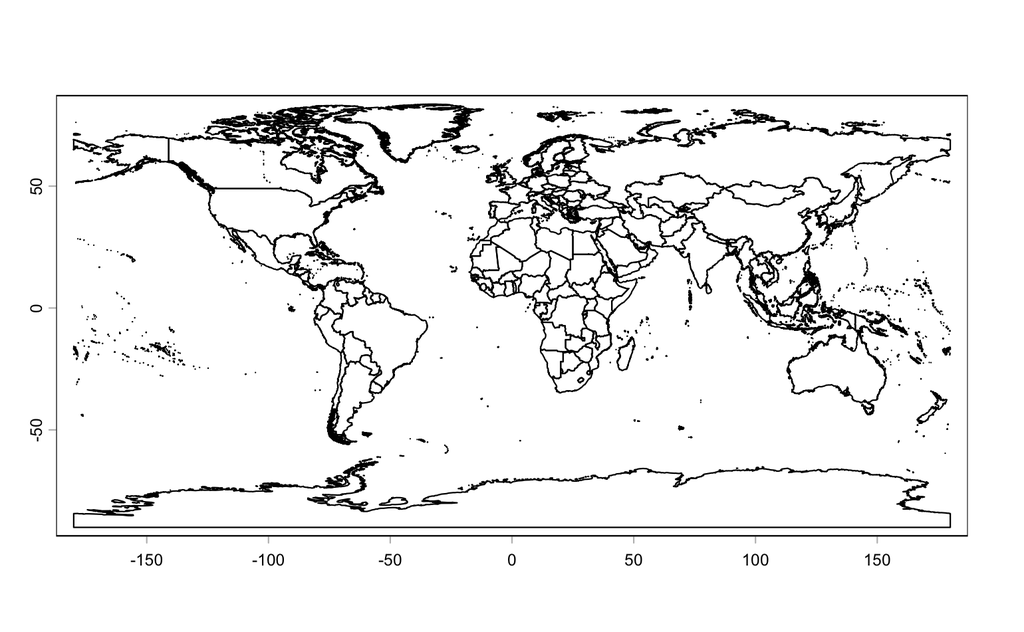

```r
#Downscaling the IPBES shape file directly from the original file
#ipbes <- vect(ipbes_shp)
#ipbesred <- simplifyGeom(ipbes, tolerance = 0.05, preserveTopology = TRUE)
#writeVector(ipbesred, "../Data_geo/ipbes_regions_subregions/ipbes_reduced.shp")

# calling the reduced shape (time saver)
ipbesred <- vect(ipbes_shp[1])
plot(ipbesred)
```

```r
NA
NA
```

# 2. GLOBIO cube metadata

```r
globio05       <- ebv_properties(dc$globio_lu_05, verbose = FALSE)
globio05_paths <- ebv_datacubepaths(dc$globio_lu_05, verbose = FALSE)

# Available scenarios: NfN [1,1] | NaC [2,1] | NfS [3,1] | BAU [4,1]
print(globio05_paths)
```

```
                 datacubepaths     scenario_names metric_names
1 scenario_1/metric_1/ebv_cube  Nature for Nature   Land cover
2 scenario_2/metric_1/ebv_cube  Nature as Culture   Land cover
3 scenario_3/metric_1/ebv_cube Nature for Society   Land cover
4 scenario_4/metric_1/ebv_cube       SSP2 RCP 6.0   Land cover
```

```r
cat("Entities:\n");   print(globio05@general$entity_names)
```

```
Entities:
 [1] "Urban"                          "Cropland"                       "Potential secondary vegetation"
 [4] "Agroforestry"                   "Pasture"                        "Rangeland"
 [7] "Forestry"                       "Secondary vegetation"           "Unmanaged forest"
[10] "Shrubland/Grassland"            "Other"                          "Bare Areas"
```

```r
cat("Timesteps:\n");  print(globio05@temporal$dates)
```

```
Timesteps:
[1] "2020-01-01" "2030-01-01" "2050-01-01" "2070-01-01"
```

```r
cat("EPSG:      ",    globio05@spatial$epsg,       "\n")
```

```
EPSG:       4326
```

```r
cat("Resolution:",    globio05@spatial$resolution, "\n")
```

```
Resolution: 0.5 0.5
```

```r
cat("Extent:    ",    globio05@spatial$extent,     "\n")
```

```
Extent:     -180 180 -90 90
```

# 3. Fraction → Area (km²): all entities × all timesteps

Working with the NfN scenario (`globio05_paths[1, 1]`). Change the row index to switch scenario. Available scenarios: NfN [1,1] | NaC [2,1] | NfS [3,1] | BAU [4,1]

```r
dc_path <- globio05_paths[1, 1]

# Pixel-area raster — latitude-varying, built once
pixel_area_km2 <- cellSize(
  rast(extent = ext(-180, 180, -90, 90), resolution = 0.5, crs = "EPSG:4326"),
  unit = "km"
)

# Metadata for the loop
entity_names      <- globio05@general$entity_names
safe_entity_names <- gsub("[[:space:]/]+", "_", entity_names)
timestep_labels   <- format(as.Date(globio05@temporal$dates), "%Y")
n_entities        <- length(entity_names)
n_timesteps       <- length(timestep_labels)

# Loop: read all timesteps per entity, convert fraction → km², name layers
globio_area_km2 <- vector("list", n_entities)
names(globio_area_km2) <- safe_entity_names

for (e in seq_len(n_entities)) {

  cat(sprintf("[%d/%d] %s\n", e, n_entities, entity_names[e]))

  frac <- ebv_read(
    filepath     = dc$globio_lu_05,
    datacubepath = dc_path,
    entity       = e,
    timestep     = seq_len(n_timesteps),
    ignore_RAM   = TRUE,
    verbose      = FALSE
  )

  area        <- frac * pixel_area_km2
  names(area) <- paste0(safe_entity_names[e], "_", timestep_labels)

  globio_area_km2[[safe_entity_names[e]]] <- area
}
```

```
[1/12] Urban
[2/12] Cropland
[3/12] Potential secondary vegetation
[4/12] Agroforestry
[5/12] Pasture
[6/12] Rangeland
[7/12] Forestry
[8/12] Secondary vegetation
[9/12] Unmanaged forest
[10/12] Shrubland/Grassland
[11/12] Other
[12/12] Bare Areas
```

```r
cat("Done.", n_entities, "entities ×", n_timesteps, "timesteps.\n")
```

```
Done. 12 entities × 4 timesteps.
```

## 3.1 Reclassifying the rasters into the six categories used for cSAR

We do the following recategorisation:

| Original categories | LUH3 reclass |
| --- | --- |
| urban | urban |
| cropland | cropland |
| potential sec. vegetation | secondary vegetation |
| agroforestry | permanent crops |
| pasture | pasture |
| rangeland | pasture |
| forestry | secondary vegetation |
| secondary vegetation | secondary vegetation |
| unmanaged forest | primary vegetation |
| shrubland/grassland | primary vegetation |
| Other, (Note: this categoty contains lichen and mosses) | primary vegetation |
| bare areas | primary vegetation |

```r
# mapping old categories to the LUH3 reclass

category_map <- c(
  Urban                           = "Urban",
  Cropland                        = "Cropland",
  Potential_secondary_vegetation  = "Secondary_vegetation",
  Agroforestry                    = "Permanent_crops",
  Pasture                         = "Pasture",
  Rangeland                       = "Pasture",
  Forestry                        = "Secondary_vegetation",
  Secondary_vegetation            = "Secondary_vegetation",
  Unmanaged_forest                = "Primary_vegetation",
  Shrubland_Grassland             = "Primary_vegetation",
  Other                           = "Primary_vegetation",
  Bare_Areas                      = "Primary_vegetation"
)

stopifnot(all(names(globio_area_km2) %in% names(category_map)))
```

Applying these changes to all other rasters

```r
new_categories <- unique(category_map)

globio_area_km2_recat <- lapply(new_categories, function(new_cat) {
  old_entities <- names(category_map)[category_map == new_cat]
  # Sum the corresponding rasters (same layer structure: 4 timesteps each)
  rasters_to_sum <- globio_area_km2[old_entities]
  summed <- Reduce(`+`, rasters_to_sum)
  names(summed) <- paste0(new_cat, "_", timestep_labels)
  summed
})

names(globio_area_km2_recat) <- new_categories

cat("Reclassified into", length(new_categories), "categories:\n")
print(new_categories)
```

# 4. Calling affinities calibration table from Martins et al (2022) cSAR—BES-SIM 1.

Affinities have been taken from the supplementary material on the paper described in the heading.

```r
 group_affinity_22 <- read.csv("../Data_geo/affinities/affinities_martins.csv")
```

The table created by Lilly has a mistake and it is related to the fact that the columns h are in reality sigmas and need to be converted. Also in the mean_h table shared by HP and made by Alexandra, there are two things to note:

1. they use a z= 0.186
2. the h values for the non-forest species are normalised to the max value (e.g. h_pasture = 2.67) as affinities shouldn’t be greater than 1.

The following chunk corrects this:

```r
sigma_cols <- group_affinity_22 %>%
  select(starts_with("sigma_")) %>%
  names()

# step 1: raw affinity per land-use type, every row
group_affinity_22 <- group_affinity_22 %>%
  mutate(across(all_of(sigma_cols),
                .fns = ~ (1 - .x)^(1 / z.value),
                .names = "h_raw_{str_remove(.col, 'sigma_')}"))

h_raw_cols <- group_affinity_22 %>%
  select(starts_with("h_raw_")) %>%
  names()

# step 2: row-wise max across land-use types (constant within Group, since sigma is broadcast)
group_affinity_22 <- group_affinity_22 %>%
  rowwise() %>%
  mutate(h_max = max(c_across(all_of(h_raw_cols)), na.rm = TRUE)) %>%
  ungroup()

# step 3: normalize only non-forest rows; leave Forest as the raw, uncapped value
group_affinity_22 <- group_affinity_22 %>%
  mutate(across(all_of(h_raw_cols),
                .fns = ~ if_else(Group == "Forest", .x, .x / h_max),
                .names = "h_{str_remove(.col, 'h_raw_')}")) %>%
  select(-all_of(h_raw_cols), -h_max)
```

Extracting h-values for the taxon groups and z-values (NOTE: z-values have been defined as 0.2 based on literature)

```r
get_h <- function(taxon) {
  row <- group_affinity_22 |> filter(Group == taxon) |> slice(1)
  c(
    Primary_vegetation   = row$h_primary_vegetation,
    Secondary_vegetation = row$h_secondary_vegetation,
    Pasture              = row$h_pastures,
    Cropland             = row$h_cropland,
    Permanent_crops      = row$h_tree_plantation,
    Urban                = row$h_urban
  )
}

h_forest    <- get_h("Forest")
h_nonforest <- get_h("Non-Forest")

z_forest    <- group_affinity_22 |>
  filter(Group == "Forest")     |>
  pull(z.value) |> unique()
z_nonforest <- group_affinity_22 |>
  filter(Group == "Non-Forest") |>
  pull(z.value) |> unique()
```

defining the timesteps for comparison

```r
t0_label <- "2020"
t1_label <- "2070"
```

# 5. Relative change in species richness at the local scale (gridcell)

Martins have defined the Relative change in species richness for each functional (or taxonomic) group $i$ between two timesteps $t$ ($t_0$ as the beginning and $t_1$ as the end of the period) as:

$$R\Delta_{i,u} = \left( \frac{\sum_j^n
h_{ij} · A_{j,u,t_1} - \sum_j^n h_{ij} · A_{j,u,t_0}}{\sum_j^n h_{ij} ·
A_{j,u,t_0}} \right)^z$$
where $A_{j,u,t}$ is the area of each land use type $j$, in each sampling unit $u$ at time $t$, derived from the recategorised rasters in the steps before, $h_{ij}$ is the affinity of the species group $i$ to the land use type $j$, $n$ is the number of land use types, and $z$ is the constant indicating the rate at which species richness increases with area.

**CORRECTION:** After reviewing the outputs which where strangely huge with HP, we came back to the formula detailed above and detected a mistake. The z-value should be applied to each species richness $(\sum_j^n h_{ij} · A_{j,u,t})$ at the different timesteps, so that the formula is written as:

$$R\Delta_{i,u} = \frac{(\sum_j^n h_{ij} ·
A_{j,u,t_1})^z - (\sum_j^n h_{ij} · A_{j,u,t_0})^z}{(\sum_j^n h_{ij} ·
A_{j,u,t_0})^z} = \left( \frac{\sum_j^n h_{ij} · A_{j,u,t_1}}{\sum_j^n
h_{ij} · A_{j,u,t_0}}\right)^z - 1$$
$$R\Delta_{i,u} = \left( \frac{\sum_j^n h_{ij} ·
A_{j,u,t_1}}{\sum_j^n h_{ij} · A_{j,u,t_0}}\right)^z - 1$$

## 5.1 Defining the Sums of species per pixel for all land uses at the different timesepts.

In the first step the function weighted_sum is defined to estimate $\sum_j^n h_{ij} · A_{j,u,t}$ for each timestep. As we are working directly with the extracted from the GLOBIO EBVcube, this section is done directly using the rasters. Note that `weighted_sum` refers to $\sum_j^n h_{ij} · A_{j,u,t}$

```r
weighted_sum <- function(h_vec, timestep_label) {
  layers <- lapply(names(h_vec), function(lu) {
    globio_area_km2_recat[[lu]][[paste0(lu, "_", timestep_label)]] * h_vec[[lu]]
  })
  Reduce(`+`, layers)
}
```

## 5.2 Estimating relative change in species richness using the `weighted_sum`

```r
rdelta_rasters <- list(
  Forest = {
    sum_t0 <- weighted_sum(h_forest, t0_label)
    sum_t1 <- weighted_sum(h_forest, t1_label)
    rdelta <- (sum_t1 / sum_t0)^z_forest - 1
    rdelta[is.infinite(rdelta)] <- NA
    names(rdelta) <- paste0("RDelta_Forest_", t0_label, "_", t1_label)
    rdelta
  },
  Non_Forest = {
    sum_t0 <- weighted_sum(h_nonforest, t0_label)
    sum_t1 <- weighted_sum(h_nonforest, t1_label)
    rdelta <- (sum_t1 / sum_t0)^z_nonforest - 1
    rdelta[is.infinite(rdelta)] <- NA
    names(rdelta) <- paste0("RDelta_NonForest_", t0_label, "_", t1_label)
    rdelta
  }
)
```

```r
summary(rdelta_rasters$Forest)
```

```r
r <- rdelta_rasters$Forest

# Convert to a data frame with coordinates for inspection
r_df <- as.data.frame(r, xy = TRUE, na.rm = TRUE)
names(r_df)[3] <- "RDelta"

# Top and bottom 1% thresholds
q_low  <- quantile(r_df$RDelta, 0.01, na.rm = TRUE)
q_high <- quantile(r_df$RDelta, 0.99, na.rm = TRUE)

cat("1st percentile:", q_low, "\n99th percentile:", q_high, "\n")

# Flag extreme pixels
r_extreme <- r
r_extreme[r_extreme > q_low & r_extreme < q_high] <- NA   # keep only tails

# ── Map 1: just the extreme pixels, overlaid on a basemap-style plot ────────

plot(r_extreme, col = c("blue", "red"), main = "Extreme RΔ pixels (top/bottom 1%) — Forest")

# ── Map 2: highlight them on top of the full RΔ raster for context ──────────

plot(r, main = "RΔ Forest with extreme pixels highlighted")
points(r_df[r_df$RDelta <= q_low | r_df$RDelta >= q_high, c("x", "y")],
       pch = 16, cex = 0.4, col = "black")
```

[output not shown]

```r
extreme_pixels <- r_df |>
  filter(RDelta <= q_low | RDelta >= q_high) |>
  arrange(RDelta)

extreme_pixels
nrow(extreme_pixels)
```

```r
ggplot() +
  geom_spatraster(data = rdelta_rasters$Forest) +
  scale_fill_gradient2(
    low = "#b2182b", mid = "#f7f7f7", high = "#2166ac",   # ColorBrewer RdBu stops
    midpoint = 0,
    na.value = NA,
    name = expression(Delta*"value")
  ) +
  coord_sf(expand = FALSE) +
  theme_void() +
  theme(legend.position = "bottom", legend.key.width = unit(2, "cm"))
```

[output not shown]

non-forest

```r
ggplot() +
  geom_spatraster(data = rdelta_rasters$Non_Forest) +
  scale_fill_gradient2(
    low = "#b2182b", mid = "#f7f7f7", high = "#2166ac",   # ColorBrewer RdBu stops
    midpoint = 0,
    na.value = NA,
    name = expression(Delta*"value")
  ) +
  coord_sf(expand = FALSE) +
  theme_void() +
  theme(legend.position = "bottom", legend.key.width = unit(2, "cm"))
```

[output not shown]

```r
summary(rdelta_rasters$Forest)
summary(rdelta_rasters$Non_Forest)
```

# 6. Global, regional and subregional totals — area and habitat-weighted area

Tables of (a) raw area per entity, and (b) habitat-weighted area per taxon group are built at three scales: global, IPBES region, and IPBES subregion. The weighted-area tables are the input to the cSAR formula at each scale.

## 6.1 Downscaling the IPBES shapefile and rasterizing regions/subregions

```r
ipbesred$Region     <- as.factor(ipbesred$Region)
ipbesred$Sub_Region <- as.factor(ipbesred$Sub_Region)
zone_region    <- rasterize(ipbesred, pixel_area_km2, field = "Region")
zone_subregion <- rasterize(ipbesred, pixel_area_km2, field = "Sub_Region")
```

## 6.2 Area totals — global, region, subregion

```r
zonal_sum <- function(r, zone, entity_name, zone_label) {
  zonal(r, zone, fun = "sum", na.rm = TRUE) |>
    pivot_longer(-1, names_to = "timestep", values_to = "area_km2") |>
    rename(zone = 1) |>
    mutate(
      entity    = entity_name,
      zone_type = zone_label,
      timestep  = gsub(paste0(entity_name, "_"), "", timestep)
    )
}
```

```r
globio_totals_df <- lapply(globio_area_km2_recat, function(r) {
  global(r, fun = "sum", na.rm = TRUE)
}) |> bind_rows(.id = "entity")
```

```r
globio_global_totals <- globio_totals_df |>
  rownames_to_column("layer") |>
  mutate(
    timestep  = mapply(function(e, l) gsub(paste0(e, "_"), "", l), entity, layer),
    zone      = "Global",
    zone_type = "Global",
    area_km2  = sum
  ) |>
  select(zone, timestep, area_km2, entity, zone_type)
```

```r
globio_region_totals <- lapply(names(globio_area_km2_recat), function(ent) {
  zonal_sum(globio_area_km2_recat[[ent]], zone_region, ent, "Region")
}) |> bind_rows()
```

```r
globio_subregion_totals <- lapply(names(globio_area_km2_recat), function(ent) {
  zonal_sum(globio_area_km2_recat[[ent]], zone_subregion, ent, "Sub_Region")
}) |> bind_rows()
```

```r
globio_zonal_totals <- bind_rows(globio_global_totals, globio_region_totals, globio_subregion_totals)
globio_zonal_totals
```

Pivoting globio_zonal_totals to set areas_year as columns

```r
globio_zonal_totals_wide <- globio_zonal_totals |>
  pivot_wider(
    names_from  = timestep,
    values_from = area_km2,
    names_prefix = "area_"
  )

globio_zonal_totals_wide
```

# 7. Relative change in species richness — global, region, subregion

For each taxon group, multiply each entity’s area total by that entity’s affinity h, sum across entities within each zone/timestep to get the weighted_areas $\sum_{j}^n h_{ij}·A_{j,u,t}$, then apply the RΔ formula between t0 and each later timestep.

```r
weighted_zonal <- function(totals_df, h_vec, taxon_name) {
  totals_df |>
    mutate(h = h_vec[entity]) |>
    mutate(across(starts_with("area_"), ~ .x * h)) |>
    group_by(zone, zone_type) |>
    summarise(across(starts_with("area_"), ~ sum(.x, na.rm = TRUE)),
              .groups = "drop") |>
    rename_with(~ gsub("^area_", "weighted_area_", .x), starts_with("area_")) |>
    mutate(taxon = taxon_name)
}
```

```r
globio_weighted_totals <- bind_rows(
  weighted_zonal(globio_zonal_totals_wide, h_forest,    "Forest"),
  weighted_zonal(globio_zonal_totals_wide, h_nonforest, "Non_Forest")
)
```

```r
z_lookup <- c(Forest = z_forest, Non_Forest = z_nonforest)

rdelta_zonal_df <- globio_weighted_totals |>
  pivot_longer(
    cols = starts_with("weighted_area_"),
    names_to  = "timestep",
    values_to = "weighted_area",
    names_prefix = "weighted_area_"
  ) |>
  group_by(zone, zone_type, taxon) |>
  filter(any(timestep == t0_label)) |>          # skip zones with no t0 baseline
  mutate(weighted_area_0 = weighted_area[timestep == t0_label]) |>
  filter(timestep != t0_label) |>
  mutate(
    weighted_area_1 = weighted_area,
    z               = z_lookup[taxon],
    RDelta          = (weighted_area_1 / weighted_area_0)^z - 1,
    RDelta          = ifelse(is.infinite(RDelta), NA, RDelta),
    year_comparison = paste0(t0_label, "_", timestep)
  ) |>
  ungroup() |>
  select(zone, zone_type, taxon, year_comparison, weighted_area_0, weighted_area_1, RDelta)

rdelta_zonal_df
```

# 8. Saving outputs

## 8.1 Results as tabular data (regional and global estimates):

```r
#convention to save the name = areas_<scenario><LU projection><date>.csv  /  rdelta_<scenario><LU projection><date>.csv

write.csv(globio_zonal_totals_wide, "../BES_results/results_biodiversity/cSAR_iDiv/areas_NfN_GLOBIO_18062026.csv")
write.csv(rdelta_zonal_df,      "../BES_results/results_biodiversity/cSAR_iDiv/rdelta_NfN_GLOBIO_18062026.csv")
```

## 8.2 Results as rasters (local estimates)

```r
#for forest species
writeRaster(rdelta_rasters$Forest, "../BES_results/results_biodiversity/cSAR_iDiv/rasters/ssdelta_forest_NfN_GLOBIO_2020-2027.tif", datatype= "FLT4S", NAflag=-9999, overwrite=TRUE)

# for non-forest species
writeRaster(rdelta_rasters$Non_Forest, "../BES_results/results_biodiversity/cSAR_iDiv/rasters/ssdelta_nonforest_NfN_GLOBIO_2020-2027.tif", datatype= "FLT4S", NAflag=-9999, overwrite=TRUE)
```